# Airbnb (ML) Project

```python
!pip install xgboost
!pip install scikit-learn
```

[output not shown]

[output cut: 21 more lines]

[output not shown]

```python
import pandas as pd
import numpy as np
import seaborn as sns
import matplotlib.pyplot as plt
from sklearn.preprocessing import OneHotEncoder
from sklearn.preprocessing import StandardScaler
from sklearn.model_selection import train_test_split
from sklearn.linear_model import LinearRegression
from sklearn.model_selection import GridSearchCV
from sklearn.linear_model import Ridge
from sklearn.linear_model import ElasticNet
from xgboost import XGBRegressor
from sklearn.metrics import mean_squared_error, r2_score

import warnings
warnings.filterwarnings('ignore')
```

```python
df = pd.read_csv("Airbnb_data - airbnb_data.csv")
```

```python
df.head(5)
```

|  | id | log_price | property_type | room_type | amenities | accommodates | bathrooms | bed_type | cancellation_policy | cleaning_fee | ... | latitude | longitude | name | neighbourhood | number_of_reviews | review_scores_rating | thumbnail_url | zipcode | bedrooms | beds |
| --- | --- | --- | --- | --- | --- | --- | --- | --- | --- | --- | --- | --- | --- | --- | --- | --- | --- | --- | --- | --- | --- |
| 0 | 6901257 | 5.010635 | Apartment | Entire home/apt | {"Wireless Internet","Air conditioning",Kitche... | 3 | 1.0 | Real Bed | strict | True | ... | 40.696524 | -73.991617 | Beautiful brownstone 1-bedroom | Brooklyn Heights | 2 | 100.0 | https://a0.muscache.com/im/pictures/6d7cbbf7-c... | 11201 | 1.0 | 1.0 |
| 1 | 6304928 | 5.129899 | Apartment | Entire home/apt | {"Wireless Internet","Air conditioning",Kitche... | 7 | 1.0 | Real Bed | strict | True | ... | 40.766115 | -73.989040 | Superb 3BR Apt Located Near Times Square | Hell's Kitchen | 6 | 93.0 | https://a0.muscache.com/im/pictures/348a55fe-4... | 10019 | 3.0 | 3.0 |
| 2 | 7919400 | 4.976734 | Apartment | Entire home/apt | {TV,"Cable TV","Wireless Internet","Air condit... | 5 | 1.0 | Real Bed | moderate | True | ... | 40.808110 | -73.943756 | The Garden Oasis | Harlem | 10 | 92.0 | https://a0.muscache.com/im/pictures/6fae5362-9... | 10027 | 1.0 | 3.0 |
| 3 | 13418779 | 6.620073 | House | Entire home/apt | {TV,"Cable TV",Internet,"Wireless Internet",Ki... | 4 | 1.0 | Real Bed | flexible | True | ... | 37.772004 | -122.431619 | Beautiful Flat in the Heart of SF! | Lower Haight | 0 | NaN | https://a0.muscache.com/im/pictures/72208dad-9... | 94117 | 2.0 | 2.0 |
| 4 | 3808709 | 4.744932 | Apartment | Entire home/apt | {TV,Internet,"Wireless Internet","Air conditio... | 2 | 1.0 | Real Bed | moderate | True | ... | 38.925627 | -77.034596 | Great studio in midtown DC | Columbia Heights | 4 | 40.0 | NaN | 20009 | 0.0 | 1.0 |

5 rows × 29 columns

```python
print(df.shape)
```

```
(74111, 29)
```

```python
print(df.columns)
```

```
Index(['id', 'log_price', 'property_type', 'room_type', 'amenities',
       'accommodates', 'bathrooms', 'bed_type', 'cancellation_policy',
       'cleaning_fee', 'city', 'description', 'first_review',
       'host_has_profile_pic', 'host_identity_verified', 'host_response_rate',
       'host_since', 'instant_bookable', 'last_review', 'latitude',
       'longitude', 'name', 'neighbourhood', 'number_of_reviews',
       'review_scores_rating', 'thumbnail_url', 'zipcode', 'bedrooms', 'beds'],
      dtype='object')
```

```python
df.info()
```

```
<class 'pandas.core.frame.DataFrame'>
RangeIndex: 74111 entries, 0 to 74110
Data columns (total 29 columns):
 #   Column                  Non-Null Count  Dtype
---  ------                  --------------  -----
 0   id                      74111 non-null  int64
 1   log_price               74111 non-null  float64
 2   property_type           74111 non-null  object
 3   room_type               74111 non-null  object
 4   amenities               74111 non-null  object
 5   accommodates            74111 non-null  int64
 6   bathrooms               73911 non-null  float64
 7   bed_type                74111 non-null  object
 8   cancellation_policy     74111 non-null  object
 9   cleaning_fee            74111 non-null  bool
```

[output cut: 21 more lines]

# Drop Irrelevant Columns

### 1) id:- Unique identifier; does not provide any predictive information.

### 2) name:- Listing title; mostly free text, not useful for numeric modeling.

### 3) description:- Long text field; difficult to quantify and not needed for price prediction.

### 4) thumbnail_url:- Image link; irrelevant to model learning or numerical analysis.

```python
df.drop(['id', 'name', 'description', 'thumbnail_url'], axis=1, inplace=True)
```

```python
df.isnull().sum()
```

```
log_price                     0
property_type                 0
room_type                     0
amenities                     0
accommodates                  0
bathrooms                   200
bed_type                      0
cancellation_policy           0
cleaning_fee                  0
city                          0
first_review              15864
host_has_profile_pic        188
host_identity_verified      188
host_response_rate        18299
host_since                  188
instant_bookable              0
last_review               15827
latitude                      0
longitude                     0
neighbourhood              6872
number_of_reviews             0
review_scores_rating      16722
zipcode                     968
bedrooms                     91
beds                        131
dtype: int64
```

## Handle Missing Values

```python
def missing_values_table(df):
    mis_val = df.isnull().sum()
    mis_val_percent = 100 * df.isnull().sum() / len(df)
    mis_val_table = pd.concat([mis_val, mis_val_percent], axis=1)
    mis_val_table = mis_val_table.rename(columns={0: 'Missing Values', 1: '% of Total Values'})
    mis_val_table = mis_val_table[mis_val_table['Missing Values'] > 0].sort_values('% of Total Values', ascending=False)
    return mis_val_table

print(missing_values_table(df))
```

```
                        Missing Values  % of Total Values
host_response_rate               18299          24.691341
review_scores_rating             16722          22.563452
first_review                     15864          21.405729
last_review                      15827          21.355804
neighbourhood                     6872           9.272578
zipcode                            968           1.306149
bathrooms                          200           0.269865
host_has_profile_pic               188           0.253674
host_identity_verified             188           0.253674
host_since                         188           0.253674
beds                               131           0.176762
bedrooms                            91           0.122789
```

```python
df.info()
```

```
<class 'pandas.core.frame.DataFrame'>
RangeIndex: 74111 entries, 0 to 74110
Data columns (total 25 columns):
 #   Column                  Non-Null Count  Dtype
---  ------                  --------------  -----
 0   log_price               74111 non-null  float64
 1   property_type           74111 non-null  object
 2   room_type               74111 non-null  object
 3   amenities               74111 non-null  object
 4   accommodates            74111 non-null  int64
 5   bathrooms               73911 non-null  float64
 6   bed_type                74111 non-null  object
 7   cancellation_policy     74111 non-null  object
 8   cleaning_fee            74111 non-null  bool
 9   city                    74111 non-null  object
```

[output cut: 17 more lines]

```python
df.host_response_rate = df.host_response_rate.str.replace('%', '', regex = True)
```

```python
df.host_response_rate = df.host_response_rate.astype(float)
```

```python
#  Function to Detect Outliers in Numeric Columns
def detect_outliers(df):
    outlier_summary = {}
    numeric_columns = df.select_dtypes(include=[np.number]).columns

    for column in numeric_columns:
        Q1 = df[column].quantile(0.25)
        Q3 = df[column].quantile(0.75)
        IQR = Q3 - Q1
        lower_bound = Q1 - 1.5 * IQR
        upper_bound = Q3 + 1.5 * IQR
        outliers = df[(df[column] < lower_bound) | (df[column] > upper_bound)]

        outliers_percentage = round((len(outliers) / len(df)) * 100, 2)

        outlier_summary[column] = {
            "Total Values": len(df),
            "Outliers": len(outliers),
            "Outlier %": outliers_percentage
        }

    # Return a summary table sorted by the highest outlier percentage
    return pd.DataFrame(outlier_summary).T.sort_values(by="Outlier %", ascending=False)
```

```python
detect_outliers(df)
```

|  | Total Values | Outliers | Outlier % |
| --- | --- | --- | --- |
| bedrooms | 74111.0 | 24236.0 | 32.70 |
| bathrooms | 74111.0 | 15812.0 | 21.34 |
| host_response_rate | 74111.0 | 12558.0 | 16.94 |
| number_of_reviews | 74111.0 | 8203.0 | 11.07 |
| beds | 74111.0 | 5686.0 | 7.67 |
| accommodates | 74111.0 | 3604.0 | 4.86 |
| review_scores_rating | 74111.0 | 1719.0 | 2.32 |
| log_price | 74111.0 | 1532.0 | 2.07 |
| longitude | 74111.0 | 0.0 | 0.00 |
| latitude | 74111.0 | 0.0 | 0.00 |

## Outlier Detection & Handling

### 1) df['bedrooms'] > 10 → 10: Any property with more than 10 bedrooms is capped at 10 (to handle unrealistic listings).

### 2) df['bathrooms'] > 8 → 8: Any listing with more than 8 bathrooms is capped at 8.

### 3) For columns ['number_of_reviews', 'beds', 'host_response_rate']:

### The function caps values above the 99th percentile to prevent rare, extreme high values from skewing the dataset.

### 4) For columns ['log_price', 'accommodates', 'review_scores_rating']:

### Values below the 1st percentile and above the 99th percentile are clipped within that range using np.clip() to smooth out both lower and upper extremes.

```python
def handle_outliers(df):
    df['bedrooms'] = np.where(df['bedrooms'] > 10, 10, df['bedrooms'])
    df['bathrooms'] = np.where(df['bathrooms'] > 8, 8, df['bathrooms'])
    for col in ['number_of_reviews', 'beds', 'host_response_rate']:
        upper_limit = df[col].quantile(0.99)
        df[col] = np.where(df[col] > upper_limit, upper_limit, df[col])
    for col in ['log_price', 'accommodates', 'review_scores_rating']:
        lower_limit = df[col].quantile(0.01)
        upper_limit = df[col].quantile(0.99)
        df[col] = np.clip(df[col], lower_limit, upper_limit)
    return df
```

```python
df = handle_outliers(df)

outlier_report_after = detect_outliers(df)
print(outlier_report_after)
```

```
                      Total Values  Outliers  Outlier %
bedrooms                   74111.0   24236.0      32.70
bathrooms                  74111.0   15812.0      21.34
host_response_rate         74111.0   12558.0      16.94
number_of_reviews          74111.0    8203.0      11.07
beds                       74111.0    5686.0       7.67
accommodates               74111.0    3604.0       4.86
review_scores_rating       74111.0    1719.0       2.32
log_price                  74111.0    1372.0       1.85
longitude                  74111.0       0.0       0.00
latitude                   74111.0       0.0       0.00
```

```python
print("Bedrooms → Min:", df['bedrooms'].min(), "Max:", df['bedrooms'].max())
print("Bathrooms → Min:", df['bathrooms'].min(), "Max:", df['bathrooms'].max())
```

```
Bedrooms → Min: 0.0 Max: 10.0
Bathrooms → Min: 0.0 Max: 8.0
```

### The plot shows how Airbnb listings are distributed by the number of bedrooms after cleaning.

### Annotating bar heights helps visualize how many listings fall into each bedroom count, making it easy to spot the most common property types.

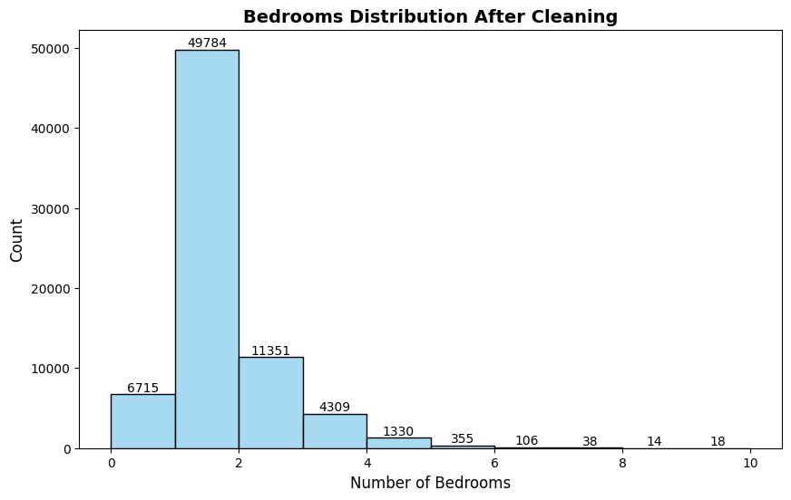

```python
import seaborn as sns
import matplotlib.pyplot as plt

plt.figure(figsize=(10,6))
bed_plot = sns.histplot(df['bedrooms'].dropna(), bins=10, stat='count', color='skyblue', edgecolor='black')

plt.title("Bedrooms Distribution After Cleaning", fontsize=14, fontweight='bold')
plt.xlabel("Number of Bedrooms", fontsize=12)
plt.ylabel("Count", fontsize=12)

for p in bed_plot.patches:
    height = p.get_height()
    if height > 0:                                                     # annotate only visible bars
        bed_plot.annotate(int(height),
                          (p.get_x() + p.get_width() / 2, height),
                          ha='center', va='bottom', fontsize=10, color='black')

plt.show()
```

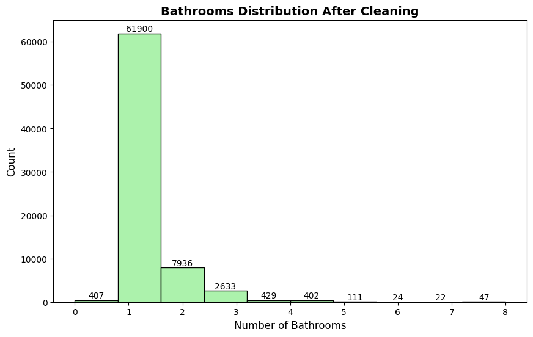

```python
import seaborn as sns
import matplotlib.pyplot as plt

plt.figure(figsize=(10,6))
bath_plot = sns.histplot(df['bathrooms'].dropna(), bins=10, stat='count', color='lightgreen',
                         edgecolor='black')

plt.title("Bathrooms Distribution After Cleaning", fontsize=14, fontweight='bold')
plt.xlabel("Number of Bathrooms", fontsize=12)
plt.ylabel("Count", fontsize=12)

for p in bath_plot.patches:
    height = p.get_height()
    if height > 0:  # annotate only visible bars
        bath_plot.annotate(int(height),
                           (p.get_x() + p.get_width()/2, height),
                           ha='center', va='bottom', fontsize=10, color='black')

plt.show()
```

```python
df.info()
```

```
<class 'pandas.core.frame.DataFrame'>
RangeIndex: 74111 entries, 0 to 74110
Data columns (total 25 columns):
 #   Column                  Non-Null Count  Dtype
---  ------                  --------------  -----
 0   log_price               74111 non-null  float64
 1   property_type           74111 non-null  object
 2   room_type               74111 non-null  object
 3   amenities               74111 non-null  object
 4   accommodates            74111 non-null  int64
 5   bathrooms               73911 non-null  float64
 6   bed_type                74111 non-null  object
 7   cancellation_policy     74111 non-null  object
 8   cleaning_fee            74111 non-null  bool
 9   city                    74111 non-null  object
```

[output cut: 17 more lines]

## Impute Missing Values

```python
def impute_missing_values(df):
    for col in df.columns:
        if df[col].dtype in [np.float64, np.int64]:
            df[col].fillna(df[col].median(), inplace=True)
        else:
            df[col].fillna('Unknown', inplace=True)
    return df
```

```python
df = impute_missing_values(df)
print("After imputing missing values:", df.isnull().sum().sum())
```

```
After imputing missing values: 0
```

```python
df.info()
```

```
<class 'pandas.core.frame.DataFrame'>
RangeIndex: 74111 entries, 0 to 74110
Data columns (total 25 columns):
 #   Column                  Non-Null Count  Dtype
---  ------                  --------------  -----
 0   log_price               74111 non-null  float64
 1   property_type           74111 non-null  object
 2   room_type               74111 non-null  object
 3   amenities               74111 non-null  object
 4   accommodates            74111 non-null  int64
 5   bathrooms               74111 non-null  float64
 6   bed_type                74111 non-null  object
 7   cancellation_policy     74111 non-null  object
 8   cleaning_fee            74111 non-null  bool
 9   city                    74111 non-null  object
```

[output cut: 17 more lines]